# Złożone schematy doboru próby

6 września 2017

## Badania na reprezentatywnych próbach losowych

## Próby losowe - nie wszędzie

W wielu dziedzinach (rodzajach badań) nie stosuje się czegoś takiego, jak losowy dobór prób (reprezentatywnych):

- klasyczne eksperymenty (randomizacja to co innego niż dobór próby);
- szerokie spektrum badań przyrodniczych;
- badania wyczerpujące (np. w makroekonomii).

## Ale dziś mówimy o:

- Sytuacji, gdy interesuje nas zbadanie cech **skończonej** populacji.
- Posiadamy *spis* wszystkich* jednostek w tej populacji, czyli tzw. **operat** losowania.
- Do uczestnictwa w badaniu wybieramy losowo tylko część populacji, czyli **próbę** (często bardzo nieliczną w stosunku do wielkości populacji).
- Procedura wybierania jednostek do próby gwarantuje, że dla każdej* z jednostek populacji jesteśmy w stanie określić prawdopodobieństwo, że zostanie ona wybrana do próby.
- Dla każdej jednostki takie prawdopodobieństwo jest niezerowe.

## Badania na próbach losowych:

Typowo stosowane w:

- szeroko pojętych naukach społecznych:
  - socjologii, psychologii, naukach politycznych,
  - badaniach edukacyjnych, badaniach rynku pracy,
- epidemiologii;
- statystyce publicznej;
  - właśnie w tym kontekście tradycyjnie rozwijane były związane z ich wykorzystaniem metody statystyczne;
- badaniach opinii publicznej (np. poparcia dla partii politycznych).

**Często wykorzystywane są w badaniach sondażowych**, a więc w sytuacji, gdy badana populacja składa się z ludzi, którzy w trakcie badania wypełniają (sami lub za pośrednictwem ankietera) pewien kwestionariusz (ankietę).

## Złożone schematy doboru próby - po co?

## Dobór prosty

Z całej populacji losujemy jednostki do próby indywidualnie, z równym prawdopodobieństwem wyboru.

[figure not shown]

## Stratyfikacja

Przed losowaniem dzielimy populację na grupy, tzw. warstwy (na podstawie cech, które znamy dla każdego w operacie), i z każdej z nich oddzielnie losujemy jednostki do próby.

Podział liczebności próby między warstwy nazywa się **alokacją**.

[figure not shown]

## Stratyfikacja cd.

- Pozwala zwiększyć precyzję wnioskowania statystycznego.
  - Stratyfikacja pomaga zapewnić, że w wyniku losowania nie otrzymamy prób o rozkładach interesujących nas zmiennych znacząco odbiegających od rozkładów populacyjnych.
  - W praktyce nie jest to proste, jeśli badanie obejmuje wiele różnych zmiennych.
- Daje możliwość prowadzenia analizy w wybranych podgrupach, nawet jeśli w populacji są niezbyt liczne.
  - Wydzielamy takie grupy jako oddzielne warstwy i losujemy z nich wystarczająco dużo jednostek.
  - Chcąc wnioskować o cechach populacji, musimy je potem odpowiednio przeważyć.

## Dobór zespołowy i wielostopniowy

Z operatu losujemy nie pojedyncze jednostki, ale całe grupy (np. szkoły, gminy, gospodarstwa domowe). Dopiero w następnym kroku z każdej z wylosowanych grup losujemy poszczególne jednostki (dobór wielostopniowy) lub włączamy do próby wszystkich z tych grup (dobór zespołowy).

[figure not shown]

## Dobór zespołowy i wielostopniowy cd.

- Pozwala zminimalizować koszty badania związane z dotarciem do respondentów.
  - Jeśli badanie wymaga osobistej obecności ankietera, a badani występują w skupiskach (terytorialnych) - np. uczniowie w szkołach, ale również mieszkańcy państwa w miejscowościach - to dużo taniej jest przebadać kilku (lub wszystkich) z jednego *skupiska*, niż tą samą liczbę osób w różnych miejscach.
- Umożliwia prowadzenie analiz wielopoziomowych.
  - Aby badać związki pomiędzy zmiennymi z różnych poziomów (np. gminy i poszczególnych mieszkańców), musimy mieć zapewnioną rozsądnie dużą liczbę obserwacji w ramach każdej z jednostek wyższego rzędu.

## Dobór zespołowy i wielostopniowy cd.

- Losowanie jednostek I stopnia z równym prawdopodobieństwem.
  - Gdy w ramach jednostek I stopnia losujemy założony odsetek jednostek II stopnia (w szczególności przy doborze zespołowym).
- Losowanie jednostek I stopnia z prawdopodobieństwem proporcjonalnym do ich liczebności.
  - Gdy w ramach każdej jednostki I stopnia losujemy założoną liczbę jednostek II stopnia.
- Losowanie jednostek I stopnia ze zwracaniem lub bez.

## A ile można stracić?

Wadą złożonych schematów doboru próby - zwłaszcza wielostopniowego i zespołowego - jest ich zwykle niższa *efektywność*. Tzn. **typowo chcąc osiągnąć określoną moc testu, musimy dobrać w sposób złożony liczniejszą próbę, niż gdyby stosować dobór prosty**.

Ile razy liczniejsza powinna być próba dobrana w dany (złożony) sposób, aby zachować precyzję szacowania schematu prostego pokazuje tzw. *efekt schematu doboru próby* (*design effect*):

\(Deff = {{D^2(\hat{X}_{złożony})} \over {D^2(\hat{X}_{prosty})}}\)

Czyli iloraz **wariancji estymatora** (nie mylić z estymatorem wariancji!) przy rozpatrywanym sposobie doboru do wariancji estymatora przy doborze prostym.

## Od czego zależy efektywność?

Efektywność schematu doboru próby zmniejsza się, gdy:

- Jednostki w ramach zespołów (jednostek losowania I rzędu) są do siebie *raczej podobne*.
  - Jednak jeśli są od siebie *raczej różne* (bywa i tak), to dobór złożony będzie bardziej efektywny niż prosty.
- Występuje zróżnicowanie prawdopodobieństwa trafienia jednostek do próby.
  - Chyba że prawdopodobieństwo doboru jest pozytywnie skorelowane ze **zmienną będącą przedmiotem naszego zainteresowania**.

W związku z tym *Deff* trudno jest szacować przed dobraniem próby.

- **Jest on specyficzny ze względu na rozpatrywaną zmienną**, a żeby go dobrze oszacować musimy być w stanie określić siłę związku między daną zmienną a prawdopodobieństwami doboru do próby.

## Przykłady w projektach badawczych

## Omnibus CBOS

- Próba dobierana na podstawie rejestru PESEL (zamawia się to w GUS).
- Realizowana liczebność ~1000 osób (losowanych zapewne ~2500).
- Warstwy ze względu na województwo i klasę wielkości miejscowości.
  - Łącznie powstaje 80 warstw.
  - Do każdej z warstw przydziela się liczbę losowanych osób tak, aby proporcja osób w danej warstwie w próbie do liczebności całej próby była zbliżona do proporcji liczebności danej warstwy w populacji do liczebności całej populacji.
  - Jest to tzw. *alokacja proporcjonalna*.

## Omnibus CBOS cd.

- Stosuje się dobór dwustopniowy:
  - Najpierw losowane są miejscowości (z prawdopodobieństwem proporcjonalnym do liczby mieszkańców miejscowości).
  - Losowanie ze zwracaniem - inaczej mielibyśmy w próbie deficyt osób z największych miast.
  - Następnie z każdej z wylosowanych miejscowości losuje się po **9 osób**.
  - Ta liczba osób z tej samej miejscowości określana jest jako *liczebność wiązki*.
  - Jeśli jakaś miejscowość została w poprzednim kroku wylosowana *m* razy, to losuje się z niej odpowiednio 9*m* osób.
- Nieco więcej szczegółów można doczytać na [stronie CBOS](http://www.cbos.pl/PL/badania/metody_realizacji.php).
- Typowo w badaniu znajdują się osoby z 235-240 różnych gmin.

## Polska próba European Social Survey

- Losowana z PESEL, ~2000 zrealizowanych wywiadów (wylosowanych osób ~2800).
- Stratyfikacja: 179 warstw według wielkości miejscowości i lokalizacji.
  - Alokacja jest proporcjonalna do populacyjnej liczebności warstwy, ale jednocześnie odwrotnie proporcjonalna do przewidywanego poziomu realizacji (*response rate*).
- W warstwach obejmujących miasta powyżej 50 tys. mieszkańców respondenci są losowani w sposób prosty.
- W pozostałych warstwach dobór dwustopniowy (podobnie jak w badaniu CBOS):
  - Najpierw losowane są miejscowości (z prawdopodobieństwem proporcjonalnym do liczby mieszkańców miejscowości).
  - Następnie z każdej z wylosowanych miejscowości losuje się po **4 osoby**.

## Inne kraje w European Social Survey

- Zdarzają się kraje, w których stosuje się dobór prosty:
  - Belgia, Dania, Szwecja.
  - Tak naprawdę te próby dobierane są losowaniem systematycznym w połączeniu z tzw. *stratyfikacją implicite*.
- W części krajów brak operatu obywateli.
  - Np. Wielka Brytania, Bułgaria, Cypr.
  - Losuje się wtedy gospodarstwa domowe (rejestry adresów występują bardziej powszechnie).
  - Po przyjściu pod dany adres ankieter spisuje członków gospodarstwa domowego i spośród nich losuje respondenta.
  - W zasadzie powinien zrobić to ściśle z założoną procedurą, ale w praktyce istnieje spora pokusa, by nie wybrać osoby, która akurat w chwili wizyty jest nieobecna.
  - Występują znaczne różnice prawdopodobieństwa wyboru respondenta do badania (jest ono większe w mniej licznych gosp. dom., a mniejsze w bardziej licznych.). Zwykle obniża to efektywność próby.

## Polska próba PISA 2012

- Próba z założenia ma być reprezentatywna dla populacji *piętnastolatków*.
- Cztery warstwy wyróżnione ze względu na typ szkoły:
  - gimnazja publiczne,
  - gimnazja niepubliczne,
  - licea ogólnokształcące,
  - inne szkoły pogimnazjalne.
- Gimnazja niepubliczne nadreprezentowane w próbie (~8% próby wobec ~2% w populacji).
  - W celu umożliwienia porównań między gimn. publicznymi a niepublicznymi.
- Szkoły losowane w ramach warstw z prawdopodobieństwem proporcjonalnym do (szacowanej na podstawie SIO) liczby uczniów *piętnastoletnich*.
- W ramach każdej ze szkół do badania losowano 30 uczniów.

## Polska próba PIRLS/TIMSS

- Próba z założenia ma być reprezentatywna dla populacji uczniów *kończących czwarty rok nauki*.
  - W Polsce w edycjach 2006 i 2011 byli to uczniowie klas III.
  - W edycji 2016 zmieniono podejście i badano uczniów klas IV.
- Próba szkół podstawowych bez warstw *explicite*.
- Szkoły losowane z prawdopodobieństwem proporcjonalnym do liczby oddziałów klasy III (lub IV).
- W ramach wylosowanych szkół losowany (prosto) jeden oddział.

## A jak to wpływa na analizy?

## Kontekst historyczny

- Metody statystyczne pozwalające wnioskować o cechach skończonych populacji na podstawie prób losowych historycznie były rozwijane głównie w kontekście statystyki publicznej.
- Klasycznym obiektem zainteresowania było tam określenie **sumy wartości zmiennej w populacji** (np. łącznej wartości, czy liczby osób, gospodarstw domowych o pewnych cechach).
  - W innych kontekstach najbardziej typowo interesujemy się estymacją średnich (szczęśliwie średnia jest liniową funkcją sumy wartości).
- Centralne pojęcie: **sampling weight**:
  - \(w_s = 1 / \pi\), gdzie \(\pi\) to prawdopodobieństwo wyboru jednostki do próby;
  - wskazuje, jak wiele jednostek w populacji *reprezentuje* dana jednostka, gdy trafia do próby.
  - Z tej interpretacji wynika sposób jej korygowania w sytuacji, gdy nie udało nam się zbadać wszystkich wylosowanych do próby.

## Estymatory punktowe

**Estymator sumy wartości populacyjnych Horvitza-Thompsona** (stosuje się do losowania ze zwracaniem, jak i bez zwracania).

\(\hat{T}_{HT} = \sum {x_i \over \pi_i}\)

gdzie \(\pi_i\) to prawdopodobieństwo wybrania *i*-tej jednostki do próby.

Od estymatora sumy populacyjnej możemy prosto przejść do estymatorów punktowych innych parametrów.

- Po prostu musimy wyrazić te parametry jako funkcje sumy wartości populacyjnych i wartości zmiennej dla poszczególnych jednostek.
- W praktyce sprowadza się to zawsze do policzenia parametru z uwzględnieniem wag, których wartości są proporcjonalne do wartości *sampling weight*.

## Wnioskowanie statystyczne

Zasadnicza trudność ze złożonymi schematami doboru próby polega na **szacowaniu wielkości wariancji (błędów standardowych) estymatorów**.

Stosowane są tu dwa wyraźnie różne od siebie podejścia:

- Opisanie *explicite* schematu doboru (z linearyzacją Taylora).
  - Dobrze podbudowane teoretycznie, ale skomplikowane w implementacji.
  - Nie do każdego parametru daje się zastosować (np. kwantyle).
  - Wymaga wykorzystania dużej ilości informacji o badanych (co może stanowić problem).
- Wykorzystanie metod replikacyjnych: jacknife bootstrap, BRR.
  - Gorzej podbudowane teoretycznie, łatwe w implementacji, ale bywa obciążające obliczeniowo.
  - Mogą być stosowane do zupełnie dowolnych parametrów.
  - Pozwalając zachować anonimowość badanych.

## Linearyzacja Taylora

Punkt wyjścia: wzór na wariancję estymatora sumy populacyjnej Horvitza-Thompsona.

Estymator Yatesa, Grundy'ego i Sena wariancji estymatora Horvitza-Thompsona:

\(\hat{D}^2(\hat{T}_{HT}) = \displaystyle\sum_{i=1}^n \sum_{j>i}^n {{\pi_i \pi_j - \pi_{ij}} \over {\pi_{ij}}} \left( {{x_i} \over {\pi_i}} - {{x_j} \over {\pi_j}} \right)^2\)

gdzie \(\pi_{ij}\) to prawdopodobieństwo, że zarówno *i*-ta jak i *j*-ta jednostka jednocześnie znajdą się w próbie.

W odróżnieniu od estymatora wariancji zaproponowanego przez samych Horvitza i Thompsona raczej nie przyjmuje wartości ujemnych. Jest jednak nieobciążony tylko w sytuacji, gdy schemat doboru próby zawsze zwraca próbę o tej samej liczebności.

## Linearyzacja Taylora cd.

- Obliczanie prawdopodobieństw znalezienia się w próbie parami może być bardzo uciążliwe.
  - W szczególności dla schematu wielostopniowego z losowaniem bez zwracania z prawdopod. prop. do wielkości jednostki na I stopniu.
  - W praktyce często wykorzystuje się aproksymacje.
- A macierz konieczna do przechowywania tych prawdopodobieństw może być bardzo duża.
- **Trzeba jeszcze wyprowadzić wzory na estymatory wariancji interesujących nas parametrów.**
  - Dla parametrów będących liniowymi funkcjami sumy populacyjnej i znanych wielkości (np. średnia) - proste.
  - Dla pozostałych parametrów ktoś musiał usiąść i wyprowadzić wzór na aproksymację przy pomocy linearyzacji Taylora (dużo ślęczenia nad pochodnymi).
  - Nie dla wszystkich parametrów linearyzacja daje dobre wyniki (np. kwantyle).

## Metody replikacyjne

Ogólna idea: Potraktuj swoją wylosowaną próbę jako populację i symuluj losowanie z niej prób (replikacji) w celu oszacowania rozkładu danego parametru. Stosowana schemat losowania powinien odpowiadać (naśladować) schematowi, w wynik którego dobrana została analizowana próba.

## Metody replikacyjne cd.

- **Jacknife:**
  - rozpatrz wszystkie możliwe replikacje powstające w wyniku usunięcia z próby (warstwy) pojedynczej obserwacji (jednostki losowania I stopnia).
- **Bootstraping:**
  - wielokrotnie losuj z próby (warstwy) ze zwracaniem replikacje równoliczne (ze względu na liczbę jednosetk losowania I stopnia) z próbą.
- **Balanced Repeated Replication (BRR):**
  - dobierz jednostki obserwacji (jednostki losowania I stopnia) w pary (pseudowarstwy) i rozpatrz wszystkie \(2n/2\) replikacje powstające w wyniku niezależnego wyboru jednej obserwacji w ramach każdej pary (pseudowarstwy).

W praktyce do celów analizy przygotowuje się zestaw zmiennych (tylu, ile jest rozpatrywanych replikacji), z których każda opisuje, które jednostki trafiły do danej replikacji, a które zostały z niej wykluczone.

## Balanced Repeated Replication (BRR)

- Metoda często wykorzystywana w badaniach edukacyjnych.
  - Ale również badaniach związanych ze zdrowiem (w Ameryce Północnej).
- Pod względem formalnym powiązana z wykorzystaniem przy doborze próby tzw. *warstwowania implicite*.
  - Sortujemy operat (w ramach warstw *explicite*) ze względu na wybrane kryteria, a następnie stosujemy losowanie systematyczne (losujemy punkt startowy i wybieramy do próby co *k*-ty element operatu).
- Jednostki wybrane w danej replikacji otrzymują wagę 2, niewybrane 0.
  - Stosuje się też modyfikację polegająca na tym, że jednostkom *wybranym* wagę się o zadaną wartość (tzw. **parametr Fay'a:** \(\varepsilon \in (0;1)\), typowo 0,5) zwiększa, a *niewybranym* zmniejsza. Daje to lepsze własności przy analizach na małych podgrupach.
  - Takie wagi trzeba jeszcze połączyć z *sampling weights*.

## Macierz wag BRR do polskiego zbioru PISA 2012

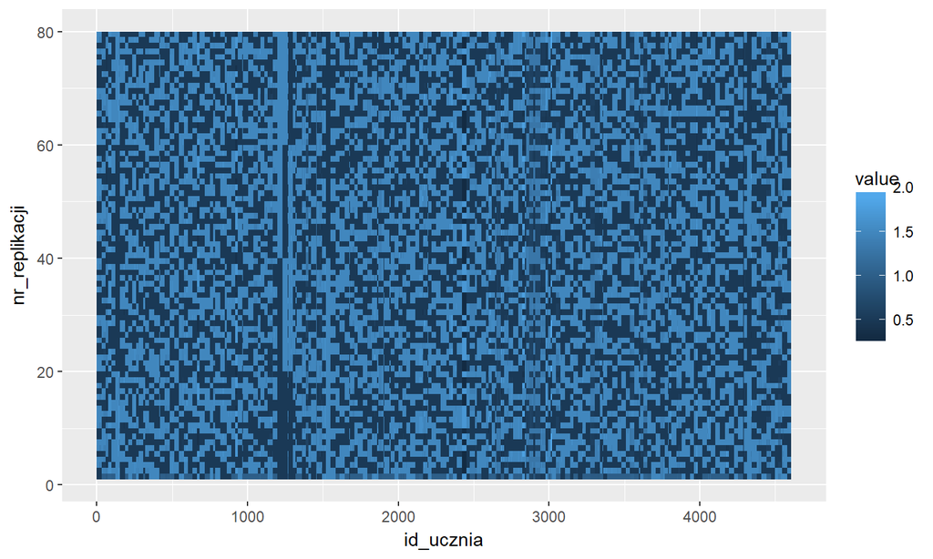

## Szacowanie wariancji estymatora BRR

Wariancję estymatora parametru \(\theta\) z wykorzystaniem BRR szacujemy jako:

\(\hat{D}_\epsilon^2 \left( \hat{\theta} \right) = {1 \over {G\varepsilon^2}} \displaystyle\sum_{i=1}^G \left( \hat{\theta}_i - \hat{\theta} \right)^2\)

- gdzie:
  - \(G\) - liczba replikacji,
  - \(\varepsilon\) parametr Fay'a,
  - \(\hat{\theta}_i\) oszacowanie parametru na podstawie *i*-tej replikacji,
  - \(\hat{\theta}\) oszacowanie na podstawie całej próby.

Jako liczbę obserwacji (na potrzeby określania liczby stopni swobody) traktujemy \(G\).

## Pakiet survey

## Co potrafi pakiet survey?

- Analizować dane z prób dobranych w sposób złożony:
  - [opisując *explicite* schemat doboru próby](https://www.rdocumentation.org/packages/survey/versions/3.32-1/topics/svydesign),
  - [korzystając z zestawu wag replikacyjnych](https://www.rdocumentation.org/packages/survey/versions/3.32-1/topics/svrepdesign).
- [Tworzyć zestawy wag replikacyjnych](https://www.rdocumentation.org/packages/survey/versions/3.32-1/topics/as.svrepdesign) (różnych typów).
- Przeprowadzić (i uwzględnić w estymacji) poststratyfikację.
  - [Klasyczna poststratyfikacja](https://www.rdocumentation.org/packages/survey/versions/3.32-1/topics/postStratify), [wagi wieńcowe (*raking*)](https://www.rdocumentation.org/packages/survey/versions/3.32-1/topics/rake), [kalibracja](https://www.rdocumentation.org/packages/survey/versions/3.32-1/topics/calibrate).
- Estymować [rozkłady brzegowe i łączne](https://www.rdocumentation.org/packages/survey/versions/3.32-1/topics/svytable) zmiennych kategorialnych.
  - Oraz przeprowadzić test niezależności \(\chi^2\).
- Estymować [typowe statystyki opisowe](https://www.rdocumentation.org/packages/survey/versions/3.32-1/topics/surveysummary):
  - sumy populacyjne, średnie, [odsetki](https://www.rdocumentation.org/packages/survey/versions/3.32-1/topics/svyciprop), wariancje;
  - [kwantyle](https://www.rdocumentation.org/packages/survey/versions/3.32-1/topics/svyquantile);
  - i ich błędy standardowe.
- …

## Co potrafi pakiet survey? cd.

- Rysować wykresy:
  - [histogramy i wykresy skrzynkowe](https://www.rdocumentation.org/packages/survey/versions/3.32-1/topics/svyhist), [wykresy rozrzutu](https://www.rdocumentation.org/packages/survey/versions/3.32-1/topics/svyplot).
- Prowadzić analizy regresji:
  - [uogólniony model liniowy](https://www.rdocumentation.org/packages/survey/versions/3.32-1/topics/svyglm), [regresja logitowa i probitowa dla porządkowej zmiennej zależnej](https://www.rdocumentation.org/packages/survey/versions/3.32-1/topics/svyolr),
  - wykonać [testy istotności liniowych kombinacji parametrów modelu](https://www.rdocumentation.org/packages/survey/versions/3.32-1/topics/regTermTest),
  - szacować wielkość efektów na podstawie [*predictive marginal means*](https://www.rdocumentation.org/packages/survey/versions/3.32-1/topics/svypredmeans).
- Prowadzić analizy przeżycia:
  - [regresja Coxa](https://www.rdocumentation.org/packages/survey/versions/3.32-1/topics/svycoxph), [krzywe Kapplana-Meiera](https://www.rdocumentation.org/packages/survey/versions/3.32-1/topics/svykm).
- Estymować model [analizy czynnikowej](https://www.rdocumentation.org/packages/survey/versions/3.32-1/topics/svyfactanal) lub przeprowadzić [analizę głównych składowych](https://www.rdocumentation.org/packages/survey/versions/3.32-1/topics/svyprcomp).
- Estymować dowolne parametry (i ich błędy standardowe):
  - Określone jako [przekształcenia innych, znanych parametrów](https://www.rdocumentation.org/packages/survey/versions/3.32-1/topics/svycontrast).
  - [Metodą największej pseudowiarygodności](https://www.rdocumentation.org/packages/survey/versions/3.32-1/topics/svymle).

## Pakiety pochodne

- **mitools** - pakiet do analizy danych z wielokrotnych imputacji braków danych (*multiple imputation*);
- **intsvy** - pakiet do analizy wyników międzynarodowych badań edukacyjnych:
  - bardzo upraszcza kwestie związane z wczytywaniem i łączeniem zbiorów danych oraz prowadzeniem typowych analiz wspieranych badań (PISA 2012, 2015; PIRLS/TIMSS 2011; PIAAC);
  - pozwala uwzględnić również kwestię opisania wyników testów umiejętności przy pomocy *plausible values*;
- **lavaan.survey** - pakiet pozwalający uwzględnić złożone schematy doboru próby w modelowaniu strukturalnym (SEM):
  - pozwala też uwzględnić zbiory z wielokrotnymi imputacjami braków danych;
  - ale działa tylko z modelami dla zmiennych ciągłych;
- **srvyr** - nakładka umożliwiająca operowanie na obiektach pakietu *survey* przy pomocy funkcji znanych z pakietu *dplyr*;

## Materiały o pakiecie survey

- Winietki dołączone do pakietu.
- Strona internetowa pakietu na [r-forge](http://r-survey.r-forge.r-project.org/survey/).
- Książka autora pakietu - Thomasa Lumleya [*Complex Surveys: A Guide to Analysis Using R*](http://r-survey.r-forge.r-project.org/svybook/).

## Czas coś przeanalizować!